# Pneumothorax in ISARIC dataset

2nd March 2021

# Incidence of pneumothorax

## Weekly chart

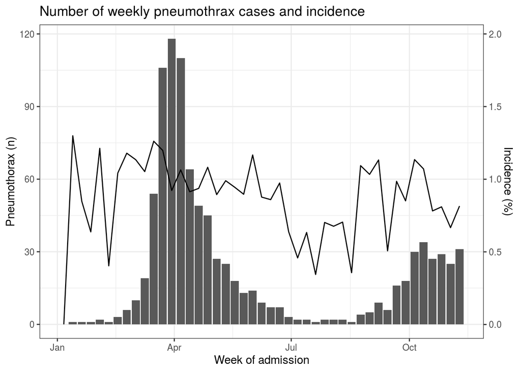

## Patient characteristics, treatment and outcomes by pneumothorax

| label | Total N | levels | No | Yes | p |
| --- | --- | --- | --- | --- | --- |
| Total N (%) |  |  | 98373 (99.0) | 959 (1.0) |  |
| Age on admission (years) | 99277 (99.9) | Median (IQR) | 73.9 (58.5 to 83.8) | 65.0 (54.7 to 75.5) | <0.001 |
| Age group | 99277 (99.9) | <50 | 14499 (14.7) | 161 (16.8) | <0.001 |
|  |  | 50-69 | 26735 (27.2) | 437 (45.6) |  |
|  |  | 70-79 | 22119 (22.5) | 207 (21.6) |  |
|  |  | 80+ | 34966 (35.6) | 153 (16.0) |  |
| Sex at Birth | 99332 (100.0) | Male | 54659 (55.6) | 652 (68.0) | <0.001 |
|  |  | Female | 43714 (44.4) | 307 (32.0) |  |
| COVID wave (15th August cut-off) | 99332 (100.0) | 1st | 71309 (72.5) | 723 (75.4) | 0.049 |
|  |  | 2nd | 27064 (27.5) | 236 (24.6) |  |
| Respiratory rate | 95934 (96.6) | <20 | 35351 (37.2) | 242 (26.2) | <0.001 |
|  |  | 20-29 | 45692 (48.1) | 445 (48.3) |  |
|  |  | >=30 | 13969 (14.7) | 235 (25.5) |  |
| Oxygen saturation | 95905 (96.5) | >=92 | 76790 (80.8) | 633 (68.4) | <0.001 |
|  |  | <92 | 18190 (19.2) | 292 (31.6) |  |
| Glasgow Coma Score | 91281 (91.9) | 15 | 79032 (87.4) | 725 (84.0) | 0.003 |
|  |  | <15 | 11386 (12.6) | 138 (16.0) |  |
| Blood Urea Nitrogen (urea) | 75313 (75.8) | <7 | 37795 (50.7) | 384 (49.0) | 0.043 |
|  |  | 7-14 | 25138 (33.7) | 295 (37.6) |  |
|  |  | >14 | 11596 (15.6) | 105 (13.4) |  |
| C-reactive protein (CRP) | 76660 (77.2) | <50 | 28302 (37.3) | 179 (23.0) | <0.001 |
|  |  | 50-99 | 17786 (23.4) | 165 (21.2) |  |
|  |  | >=100 | 29794 (39.3) | 434 (55.8) |  |
| Chest pain | 86202 (86.8) | No | 74218 (86.9) | 632 (78.9) | <0.001 |
|  |  | Yes | 11183 (13.1) | 169 (21.1) |  |
| Shortness of breath (Dyspnea) | 93548 (94.2) | No | 36558 (39.5) | 189 (21.1) | <0.001 |
|  |  | Yes | 56093 (60.5) | 708 (78.9) |  |
| Smoking | 59444 (59.8) | Never Smoked | 32178 (54.7) | 320 (48.9) | 0.005 |
|  |  | Former Smoker | 21233 (36.1) | 259 (39.5) |  |
|  |  | Smoker | 5378 (9.1) | 76 (11.6) |  |
| Asthma (physician diagnosed) | 96146 (96.8) | No | 82339 (86.5) | 757 (83.3) | 0.006 |
|  |  | Yes | 12898 (13.5) | 152 (16.7) |  |
| Chronic pulmonary disease (not asthma) | 96329 (97.0) | No | 78907 (82.7) | 743 (81.7) | 0.475 |
|  |  | Yes | 16513 (17.3) | 166 (18.3) |  |
| Obesity (as defined by clinical staff) | 86038 (86.6) | No | 74652 (87.6) | 693 (82.9) | <0.001 |
|  |  | Yes | 10550 (12.4) | 143 (17.1) |  |
| Chronic cardiac disease | 96331 (97.0) | No | 64969 (68.1) | 717 (78.2) | <0.001 |
|  |  | Yes | 30445 (31.9) | 200 (21.8) |  |
| Hypertension | 70932 (71.4) | No | 37050 (52.7) | 381 (58.3) | 0.005 |
|  |  | Yes | 33229 (47.3) | 272 (41.7) |  |
| Chronic kidney disease | 96159 (96.8) | No | 78957 (82.9) | 806 (88.8) | <0.001 |
|  |  | Yes | 16294 (17.1) | 102 (11.2) |  |
| Mild Liver disease | 95434 (96.1) | No | 93002 (98.4) | 893 (98.8) | 0.414 |
|  |  | Yes | 1528 (1.6) | 11 (1.2) |  |
| Malignant neoplasm | 95729 (96.4) | No | 85234 (89.9) | 799 (87.6) | 0.026 |
|  |  | Yes | 9583 (10.1) | 113 (12.4) |  |
| Diabetes | 99041 (99.7) | No | 77961 (79.5) | 776 (81.3) | 0.190 |
|  |  | Yes | 20125 (20.5) | 179 (18.7) |  |
| Death | 98640 (99.3) | No | 70846 (72.5) | 475 (49.9) | <0.001 |
|  |  | Yes | 26842 (27.5) | 477 (50.1) |  |
| Any steroid | 96362 (97.0) | No | 72285 (75.7) | 517 (57.6) | <0.001 |
|  |  | Yes | 23180 (24.3) | 380 (42.4) |  |
| Respiratory support | 98729 (99.4) | None | 27733 (28.4) | 44 (4.6) | <0.001 |
|  |  | Oxygen therapy | 53310 (54.5) | 308 (32.2) |  |
|  |  | NIV only | 10040 (10.3) | 97 (10.1) |  |
|  |  | IMV only | 2572 (2.6) | 157 (16.4) |  |
|  |  | IMV & NIV | 4118 (4.2) | 350 (36.6) |  |
| ICU/HDU admission | 99222 (99.9) | No | 85267 (86.8) | 359 (37.5) | <0.001 |
|  |  | Yes | 12997 (13.2) | 599 (62.5) |  |
| Days in ICU/HDU | 98126 (98.8) | None | 85267 (87.7) | 359 (37.9) | <0.001 |
|  |  | Less than 4 days | 3068 (3.2) | 76 (8.0) |  |
|  |  | 4 to 7 days | 2972 (3.1) | 91 (9.6) |  |
|  |  | 8 to 14 days | 2603 (2.7) | 130 (13.7) |  |
|  |  | 15 days or more | 3270 (3.4) | 290 (30.7) |  |

## Risk factors for pneumothorax (all patients included)

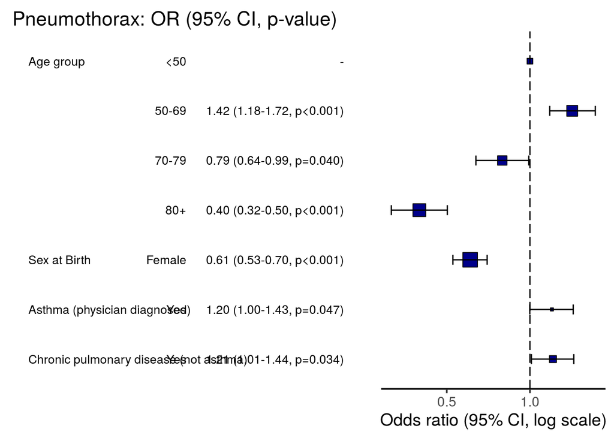

## Risk factors for spontaneous pneumothorax (ward patients not on mechanical ventilation included)

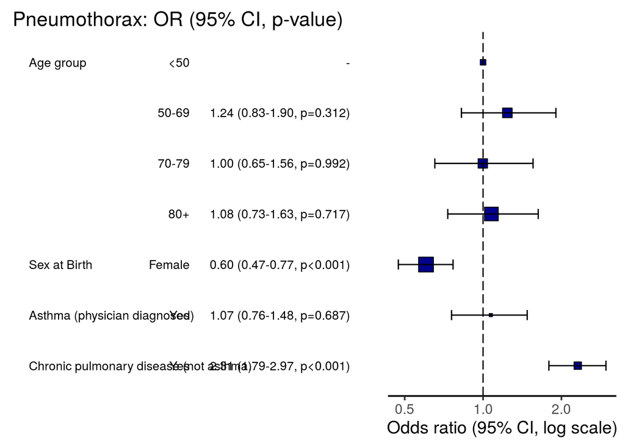

## Risk factors for pneumothorax in ICU/HDU patients

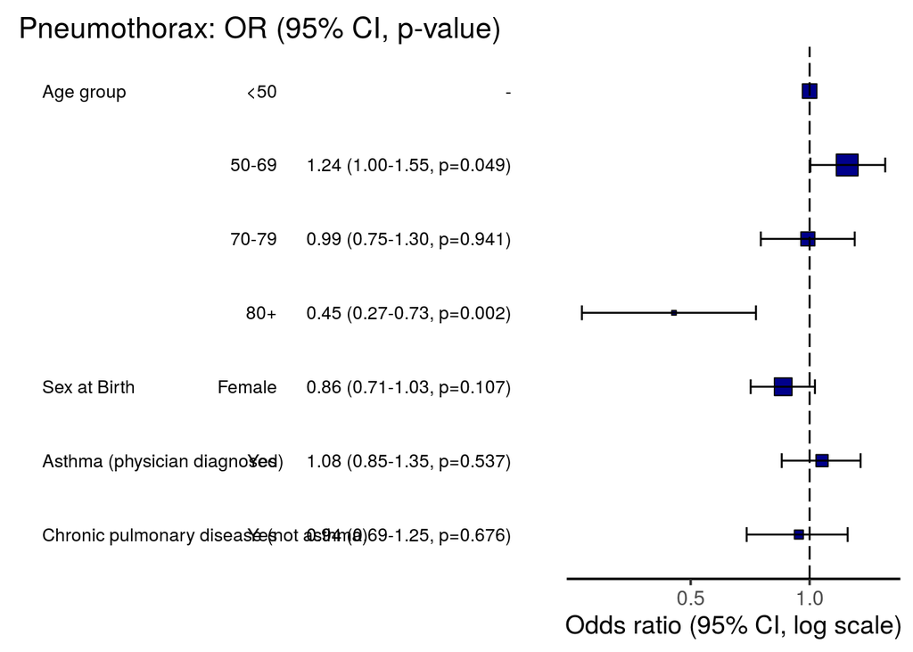

## Pneumothorax stratified by respiratory support

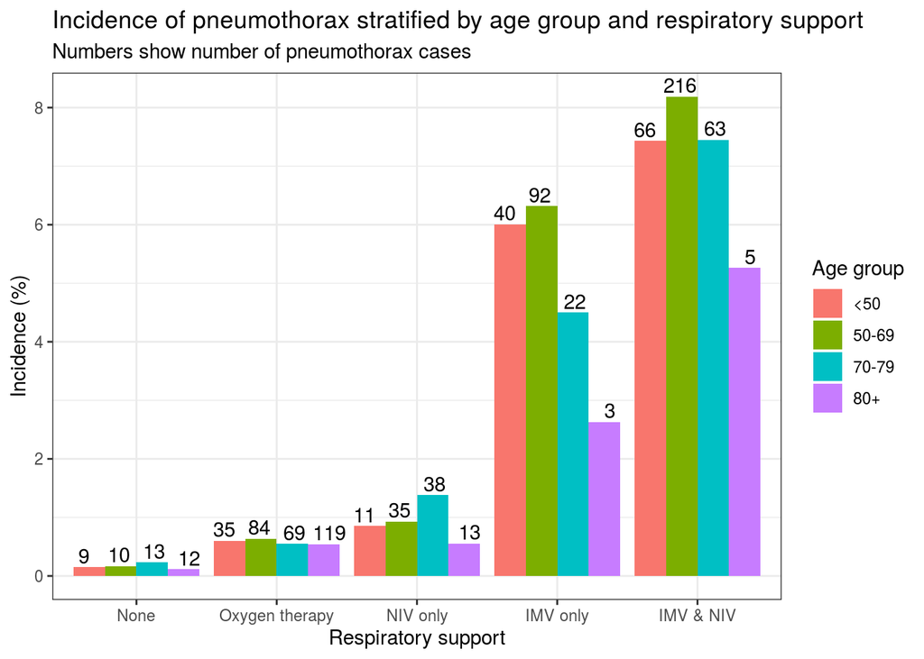

| label | Total N | levels | None | Oxygen therapy | NIV only | IMV only | IMV & NIV | p |
| --- | --- | --- | --- | --- | --- | --- | --- | --- |
| Total N (%) |  |  | 44 (4.6) | 308 (32.2) | 97 (10.1) | 157 (16.4) | 350 (36.6) |  |
| Age on admission (years) | 955 (99.9) | Median (IQR) | 71.4 (58.1 to 80.3) | 76.0 (62.8 to 83.5) | 70.0 (59.9 to 76.4) | 56.4 (50.0 to 65.5) | 61.5 (53.6 to 68.1) | <0.001 |
| Age group | 955 (99.9) | <50 | 9 (20.5) | 35 (11.4) | 11 (11.3) | 40 (25.5) | 66 (18.9) | <0.001 |
|  |  | 50-69 | 10 (22.7) | 84 (27.4) | 35 (36.1) | 92 (58.6) | 216 (61.7) |  |
|  |  | 70-79 | 13 (29.5) | 69 (22.5) | 38 (39.2) | 22 (14.0) | 63 (18.0) |  |
|  |  | 80+ | 12 (27.3) | 119 (38.8) | 13 (13.4) | 3 (1.9) | 5 (1.4) |  |
| Sex at Birth | 956 (100.0) | Male | 33 (75.0) | 194 (63.0) | 60 (61.9) | 106 (67.5) | 256 (73.1) | 0.033 |
|  |  | Female | 11 (25.0) | 114 (37.0) | 37 (38.1) | 51 (32.5) | 94 (26.9) |  |
| COVID wave (15th August cut-off) | 956 (100.0) | 1st | 32 (72.7) | 239 (77.6) | 69 (71.1) | 134 (85.4) | 247 (70.6) | 0.005 |
|  |  | 2nd | 12 (27.3) | 69 (22.4) | 28 (28.9) | 23 (14.6) | 103 (29.4) |  |
| Respiratory rate | 921 (96.3) | <20 | 20 (46.5) | 106 (35.5) | 23 (24.2) | 43 (30.5) | 50 (14.6) | <0.001 |
|  |  | 20-29 | 15 (34.9) | 153 (51.2) | 46 (48.4) | 46 (32.6) | 185 (53.9) |  |
|  |  | >=30 | 8 (18.6) | 40 (13.4) | 26 (27.4) | 52 (36.9) | 108 (31.5) |  |
| Oxygen saturation | 924 (96.7) | >=92 | 37 (88.1) | 234 (78.5) | 64 (67.4) | 86 (59.3) | 211 (61.3) | <0.001 |
|  |  | <92 | 5 (11.9) | 64 (21.5) | 31 (32.6) | 59 (40.7) | 133 (38.7) |  |
| Glasgow Coma Score | 863 (90.3) | 15 | 36 (97.3) | 271 (92.8) | 86 (96.6) | 76 (56.3) | 256 (82.6) | <0.001 |
|  |  | <15 | 1 (2.7) | 21 (7.2) | 3 (3.4) | 59 (43.7) | 54 (17.4) |  |
| Blood Urea Nitrogen (urea) | 781 (81.7) | <7 | 21 (61.8) | 126 (50.6) | 39 (49.4) | 58 (48.3) | 140 (46.8) | 0.599 |
|  |  | 7-14 | 9 (26.5) | 86 (34.5) | 27 (34.2) | 48 (40.0) | 123 (41.1) |  |
|  |  | >14 | 4 (11.8) | 37 (14.9) | 13 (16.5) | 14 (11.7) | 36 (12.0) |  |
| C-reactive protein (CRP) | 775 (81.1) | <50 | 17 (53.1) | 86 (35.2) | 20 (25.6) | 15 (11.7) | 41 (14.0) | <0.001 |
|  |  | 50-99 | 6 (18.8) | 55 (22.5) | 15 (19.2) | 25 (19.5) | 64 (21.8) |  |
|  |  | >=100 | 9 (28.1) | 103 (42.2) | 43 (55.1) | 88 (68.8) | 188 (64.2) |  |
| Chest pain | 800 (83.7) | No | 25 (67.6) | 190 (73.4) | 61 (71.8) | 104 (87.4) | 251 (83.7) | 0.001 |
|  |  | Yes | 12 (32.4) | 69 (26.6) | 24 (28.2) | 15 (12.6) | 49 (16.3) |  |
| Shortness of breath (Dyspnea) | 896 (93.7) | No | 20 (46.5) | 89 (31.1) | 19 (20.4) | 23 (16.4) | 38 (11.4) | <0.001 |
|  |  | Yes | 23 (53.5) | 197 (68.9) | 74 (79.6) | 117 (83.6) | 296 (88.6) |  |
| Smoking | 655 (68.5) | Never Smoked | 9 (39.1) | 79 (37.4) | 36 (47.4) | 59 (66.3) | 137 (53.5) | <0.001 |
|  |  | Former Smoker | 7 (30.4) | 97 (46.0) | 30 (39.5) | 25 (28.1) | 100 (39.1) |  |
|  |  | Smoker | 7 (30.4) | 35 (16.6) | 10 (13.2) | 5 (5.6) | 19 (7.4) |  |
| Asthma (physician diagnosed) | 908 (95.0) | No | 38 (95.0) | 248 (84.9) | 70 (77.8) | 124 (83.2) | 276 (81.9) | 0.140 |
|  |  | Yes | 2 (5.0) | 44 (15.1) | 20 (22.2) | 25 (16.8) | 61 (18.1) |  |
| Chronic pulmonary disease (not asthma) | 908 (95.0) | No | 33 (82.5) | 197 (66.6) | 64 (71.9) | 138 (93.9) | 310 (92.3) | <0.001 |
|  |  | Yes | 7 (17.5) | 99 (33.4) | 25 (28.1) | 9 (6.1) | 26 (7.7) |  |
| Obesity (as defined by clinical staff) | 835 (87.3) | No | 36 (97.3) | 249 (91.2) | 64 (81.0) | 108 (77.1) | 235 (76.8) | <0.001 |
|  |  | Yes | 1 (2.7) | 24 (8.8) | 15 (19.0) | 32 (22.9) | 71 (23.2) |  |
| Chronic cardiac disease | 915 (95.7) | No | 28 (70.0) | 204 (68.0) | 71 (76.3) | 131 (89.1) | 282 (84.2) | <0.001 |
|  |  | Yes | 12 (30.0) | 96 (32.0) | 22 (23.7) | 16 (10.9) | 53 (15.8) |  |
| Hypertension | 651 (68.1) | No | 18 (50.0) | 120 (54.5) | 44 (59.5) | 49 (64.5) | 149 (60.8) | 0.384 |
|  |  | Yes | 18 (50.0) | 100 (45.5) | 30 (40.5) | 27 (35.5) | 96 (39.2) |  |
| Chronic kidney disease | 907 (94.9) | No | 32 (80.0) | 245 (82.8) | 73 (83.0) | 136 (92.5) | 319 (94.9) | <0.001 |
|  |  | Yes | 8 (20.0) | 51 (17.2) | 15 (17.0) | 11 (7.5) | 17 (5.1) |  |
| Mild Liver disease | 903 (94.5) | No | 40 (100.0) | 291 (98.0) | 88 (100.0) | 142 (97.9) | 331 (99.4) | 0.278 |
|  |  | Yes | 0 (0.0) | 6 (2.0) | 0 (0.0) | 3 (2.1) | 2 (0.6) |  |
| Malignant neoplasm | 911 (95.3) | No | 33 (78.6) | 239 (80.7) | 76 (83.5) | 137 (93.2) | 313 (93.4) | <0.001 |
|  |  | Yes | 9 (21.4) | 57 (19.3) | 15 (16.5) | 10 (6.8) | 22 (6.6) |  |
| Diabetes | 953 (99.7) | No | 35 (79.5) | 249 (80.8) | 80 (82.5) | 126 (81.3) | 284 (81.4) | 0.995 |
|  |  | Yes | 9 (20.5) | 59 (19.2) | 17 (17.5) | 29 (18.7) | 65 (18.6) |  |
| Death | 949 (99.3) | No | 31 (73.8) | 163 (53.1) | 51 (52.6) | 62 (39.7) | 168 (48.4) | 0.001 |
|  |  | Yes | 11 (26.2) | 144 (46.9) | 46 (47.4) | 94 (60.3) | 179 (51.6) |  |
| Any steroid | 895 (93.6) | No | 37 (90.2) | 222 (73.3) | 50 (53.2) | 76 (55.5) | 130 (40.6) | <0.001 |
|  |  | Yes | 4 (9.8) | 81 (26.7) | 44 (46.8) | 61 (44.5) | 190 (59.4) |  |
| ICU/HDU admission | 956 (100.0) | No | 42 (95.5) | 276 (89.6) | 39 (40.2) | 1 (0.6) | 0 (0.0) | <0.001 |
|  |  | Yes | 2 (4.5) | 32 (10.4) | 58 (59.8) | 156 (99.4) | 350 (100.0) |  |
| Days in ICU/HDU | 944 (98.7) | None | 42 (95.5) | 276 (90.5) | 39 (40.6) | 1 (0.6) | 0 (0.0) | <0.001 |
|  |  | Less than 4 days | 0 (0.0) | 12 (3.9) | 12 (12.5) | 16 (10.3) | 36 (10.5) |  |
|  |  | 4 to 7 days | 0 (0.0) | 6 (2.0) | 24 (25.0) | 20 (12.9) | 41 (11.9) |  |
|  |  | 8 to 14 days | 0 (0.0) | 4 (1.3) | 17 (17.7) | 39 (25.2) | 69 (20.1) |  |
|  |  | 15 days or more | 2 (4.5) | 7 (2.3) | 4 (4.2) | 79 (51.0) | 198 (57.6) |  |

## Pneumothorax stratified by COVID-19 wave (15th August cut-off)

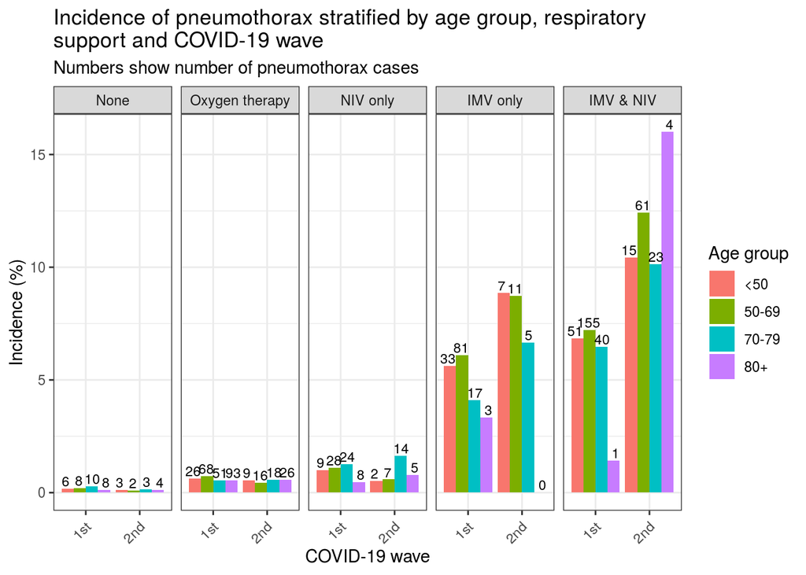

| label | Total N | levels | 1st | 2nd | p |
| --- | --- | --- | --- | --- | --- |
| Total N (%) |  |  | 723 (75.4) | 236 (24.6) |  |
| Age on admission (years) | 958 (99.9) | Median (IQR) | 64.3 (54.0 to 75.0) | 67.3 (57.5 to 76.0) | 0.059 |
| Age group | 958 (99.9) | <50 | 125 (17.3) | 36 (15.3) | 0.097 |
|  |  | 50-69 | 340 (47.1) | 97 (41.1) |  |
|  |  | 70-79 | 143 (19.8) | 64 (27.1) |  |
|  |  | 80+ | 114 (15.8) | 39 (16.5) |  |
| Sex at Birth | 959 (100.0) | Male | 485 (67.1) | 167 (70.8) | 0.331 |
|  |  | Female | 238 (32.9) | 69 (29.2) |  |
| Respiratory rate | 922 (96.1) | <20 | 179 (25.8) | 63 (27.8) | 0.798 |
|  |  | 20-29 | 336 (48.3) | 109 (48.0) |  |
|  |  | >=30 | 180 (25.9) | 55 (24.2) |  |
| Oxygen saturation | 925 (96.5) | >=92 | 478 (68.5) | 155 (68.3) | 1.000 |
|  |  | <92 | 220 (31.5) | 72 (31.7) |  |
| Glasgow Coma Score | 863 (90.0) | 15 | 535 (82.6) | 190 (88.4) | 0.057 |
|  |  | <15 | 113 (17.4) | 25 (11.6) |  |
| Blood Urea Nitrogen (urea) | 784 (81.8) | <7 | 301 (51.0) | 83 (42.8) | 0.014 |
|  |  | 7-14 | 205 (34.7) | 90 (46.4) |  |
|  |  | >14 | 84 (14.2) | 21 (10.8) |  |
| C-reactive protein (CRP) | 778 (81.1) | <50 | 135 (22.7) | 44 (24.0) | 0.555 |
|  |  | 50-99 | 122 (20.5) | 43 (23.5) |  |
|  |  | >=100 | 338 (56.8) | 96 (52.5) |  |
| Chest pain | 801 (83.5) | No | 460 (77.8) | 172 (81.9) | 0.253 |
|  |  | Yes | 131 (22.2) | 38 (18.1) |  |
| Shortness of breath (Dyspnea) | 897 (93.5) | No | 138 (20.5) | 51 (22.8) | 0.532 |
|  |  | Yes | 535 (79.5) | 173 (77.2) |  |
| Smoking | 655 (68.3) | Never Smoked | 261 (51.8) | 59 (39.1) | 0.016 |
|  |  | Former Smoker | 185 (36.7) | 74 (49.0) |  |
|  |  | Smoker | 58 (11.5) | 18 (11.9) |  |
| Asthma (physician diagnosed) | 909 (94.8) | No | 571 (84.0) | 186 (81.2) | 0.389 |
|  |  | Yes | 109 (16.0) | 43 (18.8) |  |
| Chronic pulmonary disease (not asthma) | 909 (94.8) | No | 570 (83.3) | 173 (76.9) | 0.038 |
|  |  | Yes | 114 (16.7) | 52 (23.1) |  |
| Obesity (as defined by clinical staff) | 836 (87.2) | No | 523 (83.1) | 170 (82.1) | 0.816 |
|  |  | Yes | 106 (16.9) | 37 (17.9) |  |
| Chronic cardiac disease | 917 (95.6) | No | 535 (77.3) | 182 (80.9) | 0.300 |
|  |  | Yes | 157 (22.7) | 43 (19.1) |  |
| Hypertension | 653 (68.1) | No | 250 (58.4) | 131 (58.2) | 1.000 |
|  |  | Yes | 178 (41.6) | 94 (41.8) |  |
| Chronic kidney disease | 908 (94.7) | No | 599 (88.1) | 207 (90.8) | 0.319 |
|  |  | Yes | 81 (11.9) | 21 (9.2) |  |
| Mild Liver disease | 904 (94.3) | No | 669 (98.8) | 224 (98.7) | 1.000 |
|  |  | Yes | 8 (1.2) | 3 (1.3) |  |
| Malignant neoplasm | 912 (95.1) | No | 602 (87.9) | 197 (86.8) | 0.749 |
|  |  | Yes | 83 (12.1) | 30 (13.2) |  |
| Diabetes | 955 (99.6) | No | 578 (80.3) | 198 (84.3) | 0.208 |
|  |  | Yes | 142 (19.7) | 37 (15.7) |  |
| Death | 952 (99.3) | No | 366 (50.7) | 109 (47.4) | 0.426 |
|  |  | Yes | 356 (49.3) | 121 (52.6) |  |
| Any steroid | 897 (93.5) | No | 458 (69.0) | 59 (25.3) | <0.001 |
|  |  | Yes | 206 (31.0) | 174 (74.7) |  |
| Respiratory support | 956 (99.7) | None | 32 (4.4) | 12 (5.1) | 0.005 |
|  |  | Oxygen therapy | 239 (33.1) | 69 (29.4) |  |
|  |  | NIV only | 69 (9.6) | 28 (11.9) |  |
|  |  | IMV only | 134 (18.6) | 23 (9.8) |  |
|  |  | IMV & NIV | 247 (34.3) | 103 (43.8) |  |
| ICU/HDU admission | 958 (99.9) | No | 280 (38.7) | 79 (33.6) | 0.184 |
|  |  | Yes | 443 (61.3) | 156 (66.4) |  |
| Days in ICU/HDU | 946 (98.6) | None | 280 (39.3) | 79 (33.9) | 0.028 |
|  |  | Less than 4 days | 56 (7.9) | 20 (8.6) |  |
|  |  | 4 to 7 days | 63 (8.8) | 28 (12.0) |  |
|  |  | 8 to 14 days | 86 (12.1) | 44 (18.9) |  |
|  |  | 15 days or more | 228 (32.0) | 62 (26.6) |  |

## Pneumothorax stratified by ICU/HDU admission and duration

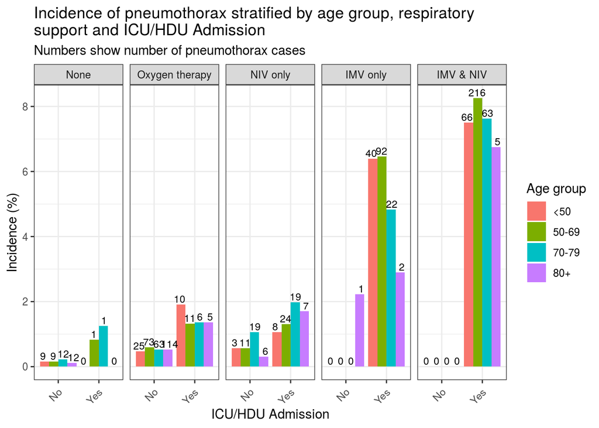

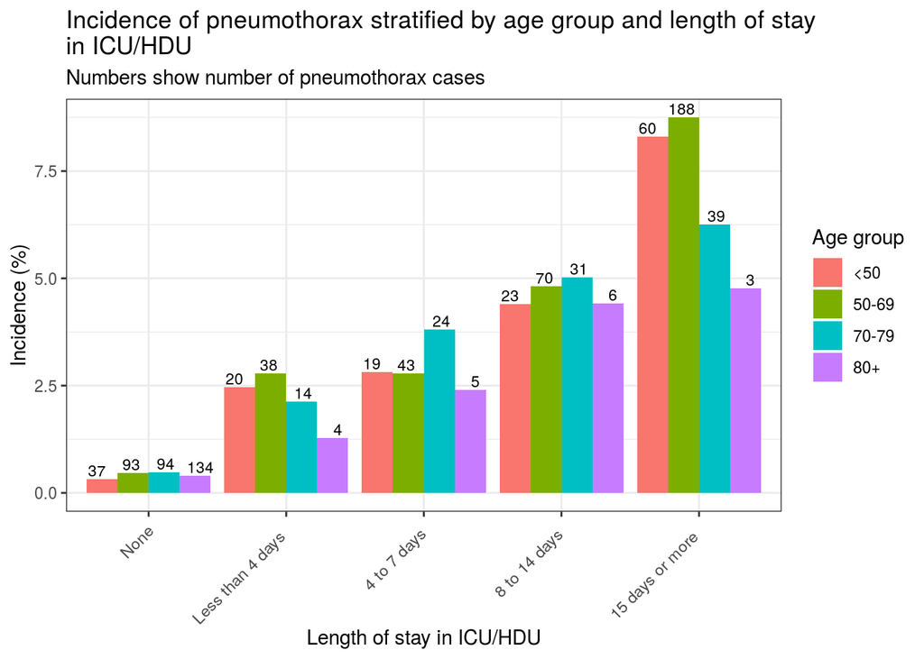

## Pneumothorax stratified by steroid treatment

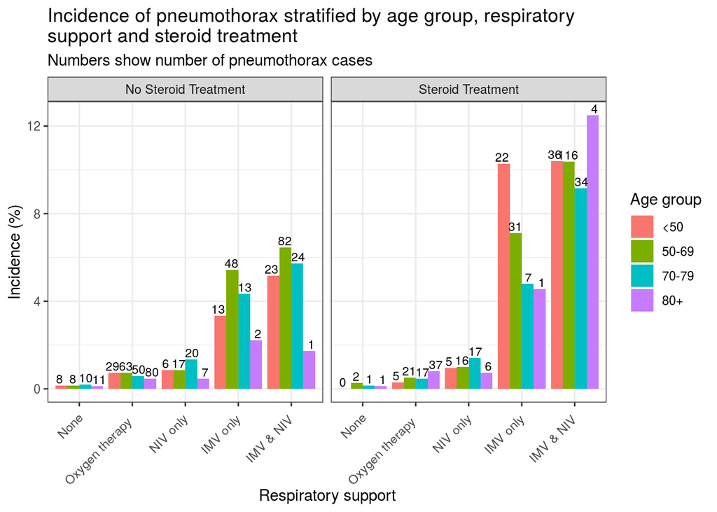

# Mortality

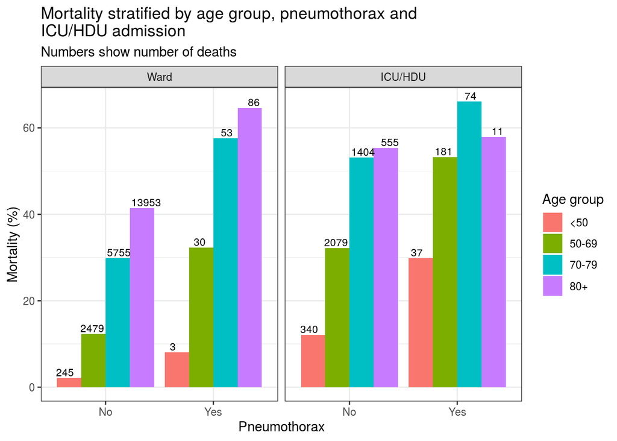

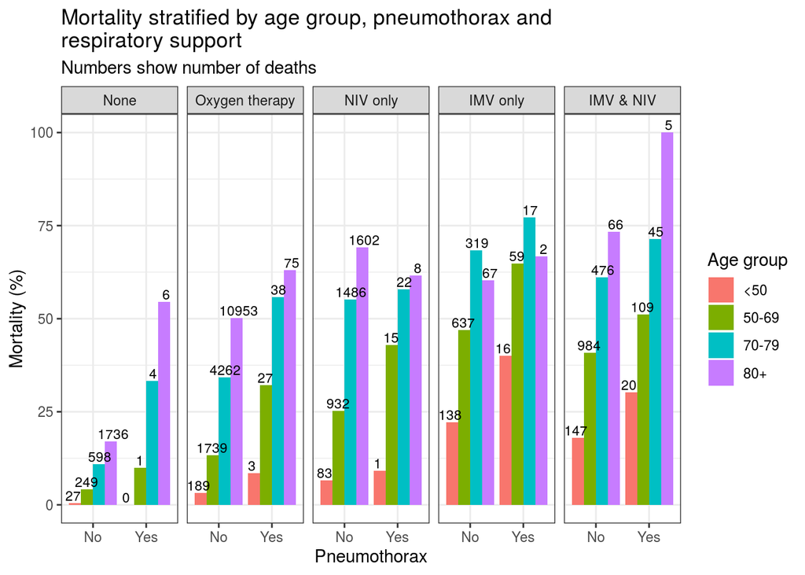

## Mortality risk factors (All patients)

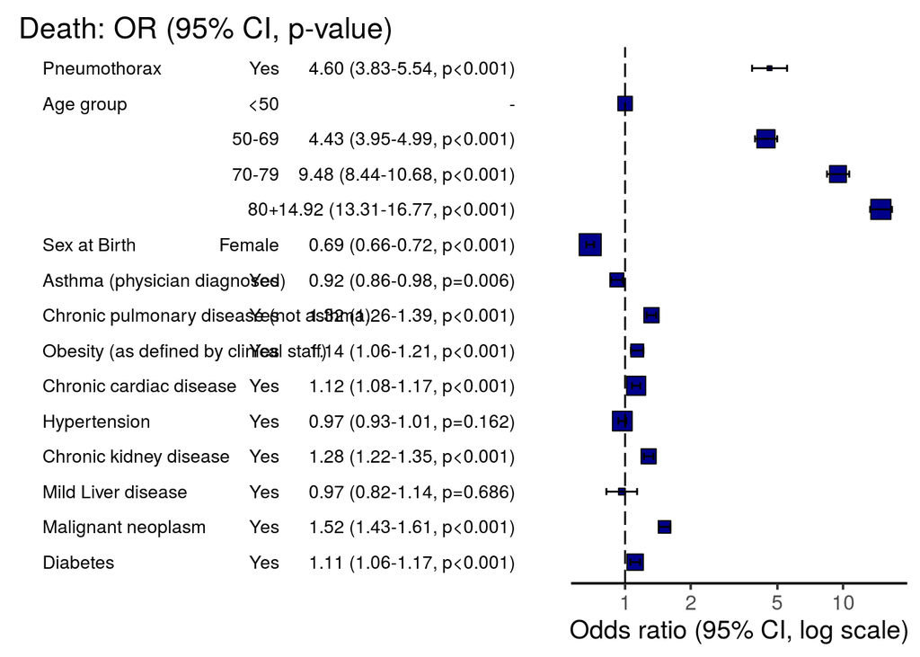

## Mortality risk factors (ward patients not on mechanical ventilation)

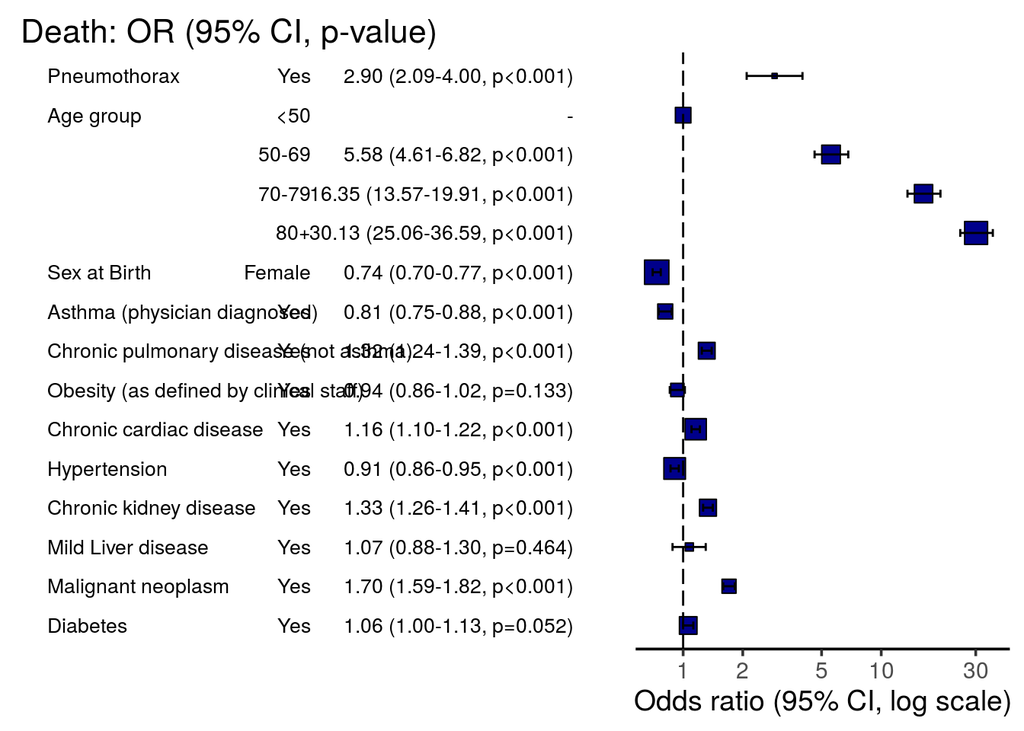

## Mortality risk factors (ICU/HDU patients)

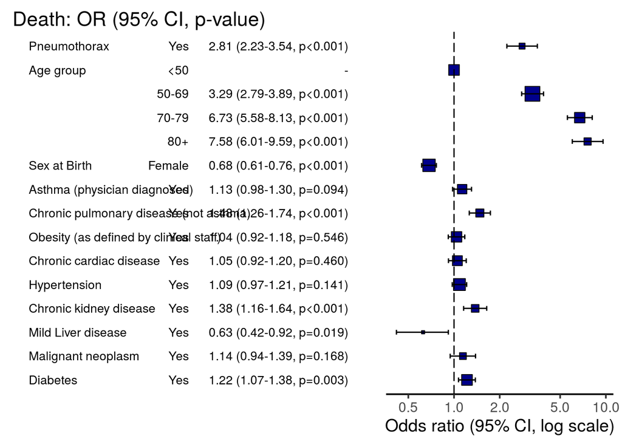

## Mortality in patients with pneumothorax

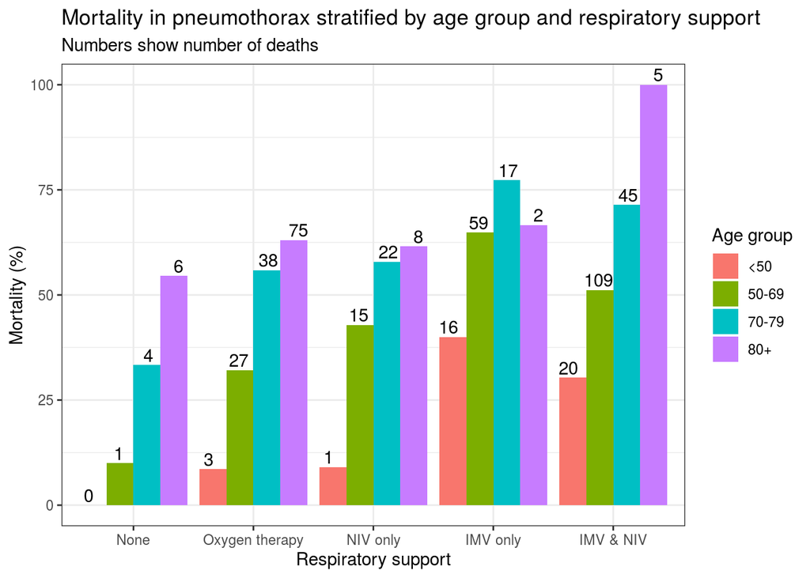

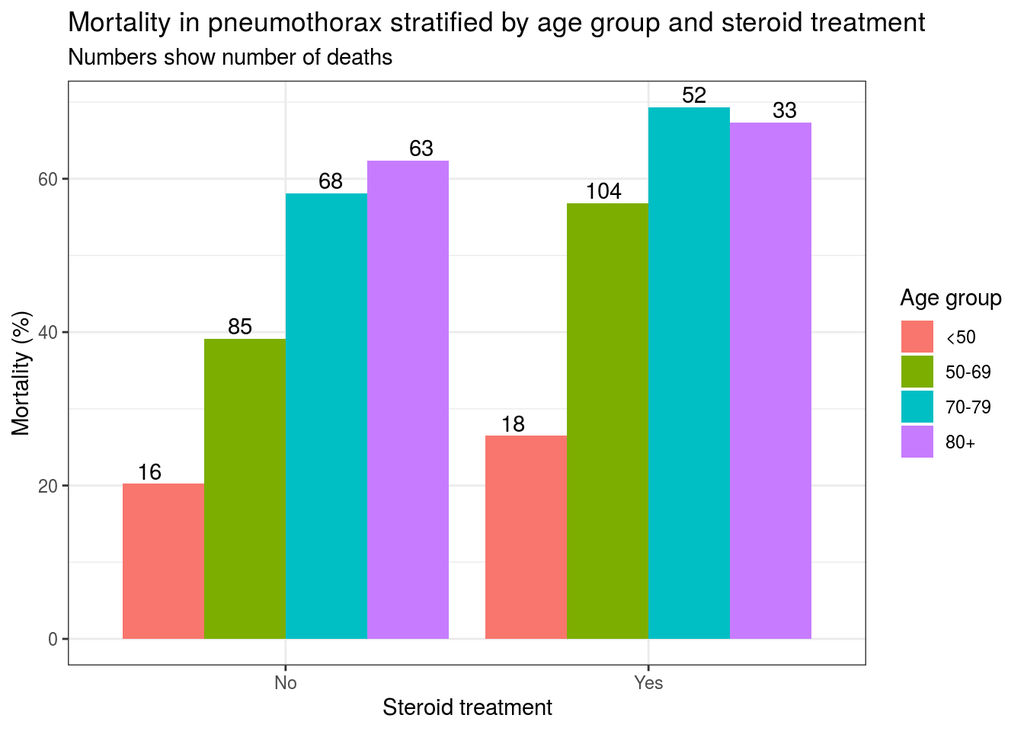

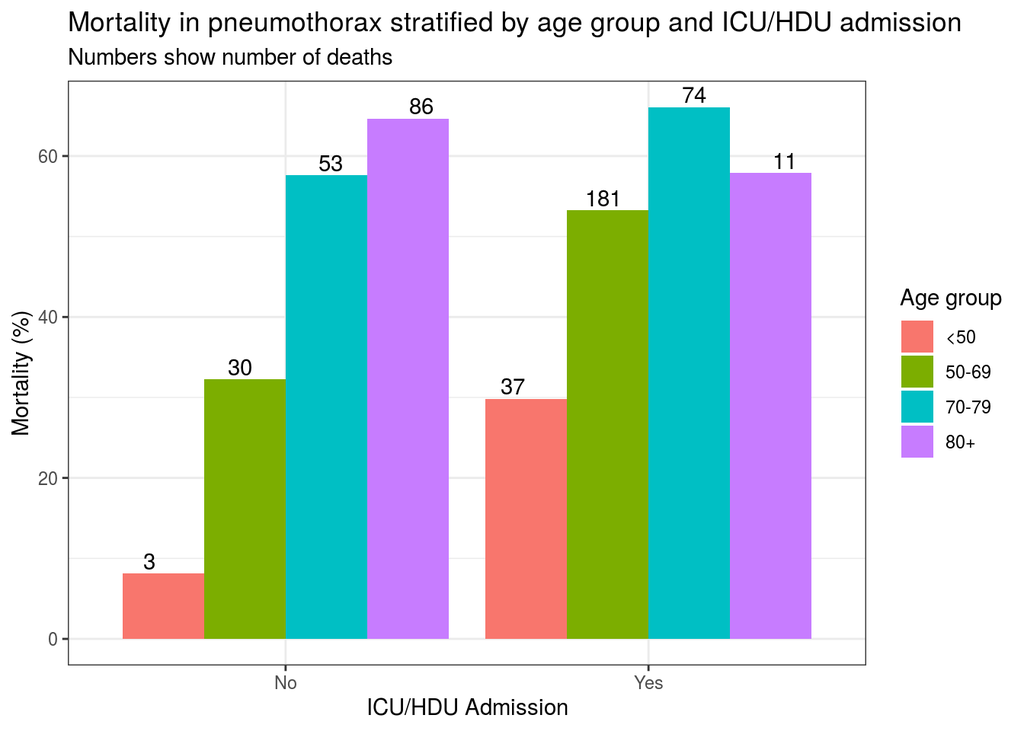

## Pneumothorax patient characteristics, treatment stratified by death

| label | Total N | levels | No | Yes | p |
| --- | --- | --- | --- | --- | --- |
| Total N (%) |  |  | 475 (49.9) | 477 (50.1) |  |
| Age on admission (years) | 951 (99.9) | Median (IQR) | 61.0 (49.7 to 71.4) | 68.8 (59.0 to 77.9) | <0.001 |
| Age group | 951 (99.9) | <50 | 121 (25.5) | 40 (8.4) | <0.001 |
|  |  | 50-69 | 222 (46.7) | 211 (44.3) |  |
|  |  | 70-79 | 77 (16.2) | 128 (26.9) |  |
|  |  | 80+ | 55 (11.6) | 97 (20.4) |  |
| Sex at Birth | 952 (100.0) | Male | 315 (66.3) | 332 (69.6) | 0.309 |
|  |  | Female | 160 (33.7) | 145 (30.4) |  |
| COVID wave (15th August cut-off) | 952 (100.0) | 1st | 366 (77.1) | 356 (74.6) | 0.426 |
|  |  | 2nd | 109 (22.9) | 121 (25.4) |  |
| Respiratory rate | 915 (96.1) | <20 | 121 (26.2) | 120 (26.4) | 0.619 |
|  |  | 20-29 | 228 (49.5) | 212 (46.7) |  |
|  |  | >=30 | 112 (24.3) | 122 (26.9) |  |
| Oxygen saturation | 918 (96.4) | >=92 | 336 (73.0) | 291 (63.5) | 0.002 |
|  |  | <92 | 124 (27.0) | 167 (36.5) |  |
| Glasgow Coma Score | 856 (89.9) | 15 | 371 (85.7) | 348 (82.3) | 0.205 |
|  |  | <15 | 62 (14.3) | 75 (17.7) |  |
| Blood Urea Nitrogen (urea) | 777 (81.6) | <7 | 236 (60.1) | 145 (37.8) | <0.001 |
|  |  | 7-14 | 127 (32.3) | 165 (43.0) |  |
|  |  | >14 | 30 (7.6) | 74 (19.3) |  |
| C-reactive protein (CRP) | 771 (81.0) | <50 | 102 (26.4) | 75 (19.5) | 0.039 |
|  |  | 50-99 | 84 (21.8) | 79 (20.5) |  |
|  |  | >=100 | 200 (51.8) | 231 (60.0) |  |
| Chest pain | 795 (83.5) | No | 297 (73.7) | 330 (84.2) | <0.001 |
|  |  | Yes | 106 (26.3) | 62 (15.8) |  |
| Shortness of breath (Dyspnea) | 890 (93.5) | No | 99 (22.0) | 87 (19.7) | 0.442 |
|  |  | Yes | 350 (78.0) | 354 (80.3) |  |
| Smoking | 651 (68.4) | Never Smoked | 176 (51.5) | 141 (45.6) | <0.001 |
|  |  | Former Smoker | 111 (32.5) | 148 (47.9) |  |
|  |  | Smoker | 55 (16.1) | 20 (6.5) |  |
| Asthma (physician diagnosed) | 904 (95.0) | No | 365 (81.1) | 387 (85.2) | 0.116 |
|  |  | Yes | 85 (18.9) | 67 (14.8) |  |
| Chronic pulmonary disease (not asthma) | 904 (95.0) | No | 372 (83.2) | 368 (80.5) | 0.334 |
|  |  | Yes | 75 (16.8) | 89 (19.5) |  |
| Obesity (as defined by clinical staff) | 832 (87.4) | No | 336 (81.6) | 356 (84.8) | 0.253 |
|  |  | Yes | 76 (18.4) | 64 (15.2) |  |
| Chronic cardiac disease | 912 (95.8) | No | 377 (83.2) | 336 (73.2) | <0.001 |
|  |  | Yes | 76 (16.8) | 123 (26.8) |  |
| Hypertension | 648 (68.1) | No | 209 (63.9) | 168 (52.3) | 0.004 |
|  |  | Yes | 118 (36.1) | 153 (47.7) |  |
| Chronic kidney disease | 903 (94.9) | No | 408 (90.7) | 393 (86.8) | 0.080 |
|  |  | Yes | 42 (9.3) | 60 (13.2) |  |
| Mild Liver disease | 899 (94.4) | No | 441 (98.7) | 447 (98.9) | 0.985 |
|  |  | Yes | 6 (1.3) | 5 (1.1) |  |
| Malignant neoplasm | 908 (95.4) | No | 409 (91.1) | 386 (84.1) | 0.002 |
|  |  | Yes | 40 (8.9) | 73 (15.9) |  |
| Diabetes | 948 (99.6) | No | 398 (84.0) | 371 (78.3) | 0.031 |
|  |  | Yes | 76 (16.0) | 103 (21.7) |  |
| Any steroid | 890 (93.5) | No | 282 (62.7) | 232 (52.7) | 0.003 |
|  |  | Yes | 168 (37.3) | 208 (47.3) |  |
| Respiratory support | 949 (99.7) | None | 31 (6.5) | 11 (2.3) | 0.001 |
|  |  | Oxygen therapy | 163 (34.3) | 144 (30.4) |  |
|  |  | NIV only | 51 (10.7) | 46 (9.7) |  |
|  |  | IMV only | 62 (13.1) | 94 (19.8) |  |
|  |  | IMV & NIV | 168 (35.4) | 179 (37.8) |  |
| ICU/HDU admission | 951 (99.9) | No | 183 (38.5) | 173 (36.3) | 0.530 |
|  |  | Yes | 292 (61.5) | 303 (63.7) |  |
| Days in ICU/HDU | 940 (98.7) | None | 183 (39.1) | 173 (36.7) | <0.001 |
|  |  | Less than 4 days | 48 (10.3) | 28 (5.9) |  |
|  |  | 4 to 7 days | 41 (8.8) | 50 (10.6) |  |
|  |  | 8 to 14 days | 40 (8.5) | 89 (18.9) |  |
|  |  | 15 days or more | 156 (33.3) | 132 (28.0) |  |

# Path Analysis

## Interpretation of lavaan’s output

lavvan can only use a probit link rather than a logit link (as of Feb 2021). This means that odds ratios cannot be directly computed from the coefficients outputted from lavaan. However, an approximation of ‘logit coefficient $\approx$ 1.6 $\times$ probit coefficient’ can be used to obtained the following relationship (https://data.princeton.edu/wws509/r/c3s7):

Odds Ratio = exp(logit coefficient) $\approx$ exp(1.6 $\times$ probit coefficient)

For illustration, a simple model of ‘death ~ ptx’ is shown.

lavaan’s output is:

```
## lavaan 0.6-7 ended normally after 4 iterations
##
##   Estimator                                       DWLS
##   Optimization method                           NLMINB
##   Number of free parameters                          2
##
##   Number of observations                         39158
##
## Model Test User Model:
##                                               Standard      Robust
##   Test Statistic                                 0.000       0.000
##   Degrees of freedom                                 0           0
##
## Parameter Estimates:
##
##   Standard errors                           Robust.sem
##   Information                                 Expected
##   Information saturated (h1) model        Unstructured
##
## Regressions:
##                    Estimate  Std.Err  z-value  P(>|z|)
##   death ~
##     ptx               0.642    0.063   10.164    0.000
##
## Intercepts:
##                    Estimate  Std.Err  z-value  P(>|z|)
##    .death             0.000
##
## Thresholds:
##                    Estimate  Std.Err  z-value  P(>|z|)
##     death|t1          1.285    0.064   19.978    0.000
##
## Variances:
##                    Estimate  Std.Err  z-value  P(>|z|)
##    .death             1.000
##
## Scales y*:
##                    Estimate  Std.Err  z-value  P(>|z|)
##     death             1.000
```

From above, under ‘Regressions:’, the probit coeffient is 0.642. Compared with models using glm, the results are similar:

Coefficient from glm probit model is in agreement:

```
##      ptx1
## 0.6423594
```

Coefficient from glm logit model:

```
##     ptx1
## 1.044306
```

Ratio of logit coefficient to probit coefficient:

```
##     ptx1
## 1.625735
```

Estimated odds ratio using conversion factor of 1.6:

```
##     ptx1
## 2.794841
```

Actual odds ratio:

```
##     ptx1
## 2.841427
```

## Path Models

### Model 1A: Respiratory comorbidities

```
## lavaan 0.6-7 ended normally after 48 iterations
##
##   Estimator                                       DWLS
##   Optimization method                           NLMINB
##   Number of free parameters                         11
##
##   Number of observations                         39158
##
## Model Test User Model:
##                                               Standard      Robust
##   Test Statistic                                 0.000       0.000
##   Degrees of freedom                                 0           0
##
## Parameter Estimates:
##
##   Standard errors                           Robust.sem
##   Information                                 Expected
##   Information saturated (h1) model        Unstructured
##
## Regressions:
##                    Estimate  Std.Err  z-value  P(>|z|)
##   death ~
##     ptx               0.319    0.022   14.603    0.000
##     age70             0.947    0.020   47.162    0.000
##     male              0.143    0.019    7.508    0.000
##     asthma           -0.123    0.026   -4.673    0.000
##     chronicpul        0.148    0.023    6.320    0.000
##   ptx ~
##     age70            -0.302    0.039   -7.660    0.000
##     male              0.165    0.040    4.087    0.000
##     asthma            0.126    0.051    2.466    0.014
##     chronicpul        0.109    0.051    2.150    0.032
##
## Intercepts:
##                    Estimate  Std.Err  z-value  P(>|z|)
##    .death             0.000
##    .ptx               0.000
##
## Thresholds:
##                    Estimate  Std.Err  z-value  P(>|z|)
##     death|t1          2.451    0.048   50.691    0.000
##     ptx|t1            2.414    0.127   19.080    0.000
##
## Variances:
##                    Estimate  Std.Err  z-value  P(>|z|)
##    .death             0.898
##    .ptx               1.000
##
## Scales y*:
##                    Estimate  Std.Err  z-value  P(>|z|)
##     death             1.000
##     ptx               1.000
```

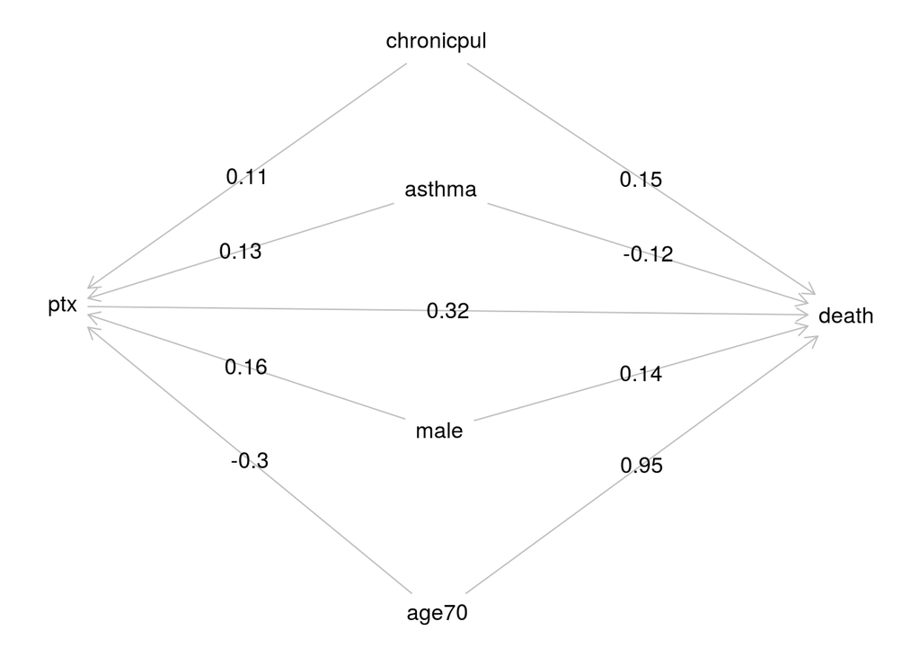

### Model 1B: All comorbidities

```
## lavaan 0.6-7 ended normally after 113 iterations
##
##   Estimator                                       DWLS
##   Optimization method                           NLMINB
##   Number of free parameters                         25
##
##   Number of observations                         39158
##
## Model Test User Model:
##                                               Standard      Robust
##   Test Statistic                                 0.000       0.000
##   Degrees of freedom                                 0           0
##
## Parameter Estimates:
##
##   Standard errors                           Robust.sem
##   Information                                 Expected
##   Information saturated (h1) model        Unstructured
##
## Regressions:
##                    Estimate  Std.Err  z-value  P(>|z|)
##   death ~
##     ptx               0.326    0.022   15.081    0.000
##     age70             0.853    0.022   39.604    0.000
##     male              0.124    0.020    6.355    0.000
##     asthma           -0.124    0.027   -4.600    0.000
##     chronicpul        0.121    0.024    5.012    0.000
##     obesity           0.034    0.027    1.255    0.210
##     chrincard         0.164    0.023    7.121    0.000
##     hypertension      0.043    0.019    2.202    0.028
##     renal             0.204    0.027    7.504    0.000
##     mildliver        -0.045    0.078   -0.583    0.560
##     malignantneo      0.236    0.029    8.040    0.000
##     diabetes          0.069    0.024    2.930    0.003
##   ptx ~
##     age70            -0.248    0.044   -5.695    0.000
##     male              0.178    0.041    4.294    0.000
##     asthma            0.121    0.052    2.327    0.020
##     chronicpul        0.125    0.052    2.402    0.016
##     obesity           0.096    0.054    1.798    0.072
```

[output cut: 11 more lines]

```
##
## Thresholds:
##                    Estimate  Std.Err  z-value  P(>|z|)
##     death|t1          3.075    0.089   34.680    0.000
##     ptx|t1            2.355    0.246    9.565    0.000
##
## Variances:
##                    Estimate  Std.Err  z-value  P(>|z|)
##    .death             0.894
##    .ptx               1.000
##
## Scales y*:
##                    Estimate  Std.Err  z-value  P(>|z|)
##     death             1.000
##     ptx               1.000
```

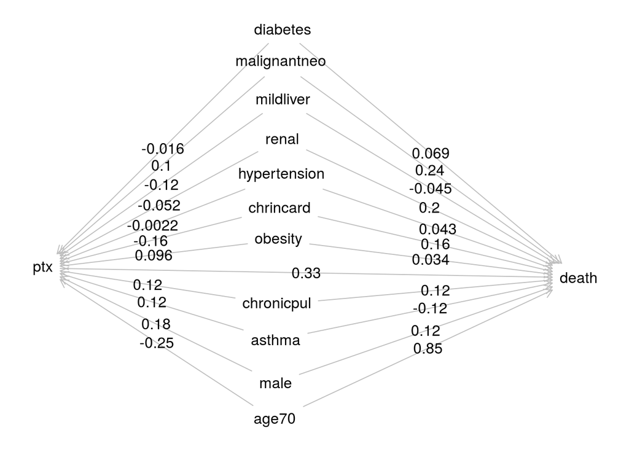

### Model 2: Vital signs

Modifications: Add vital signs to model.

Note: Age, sex and comorbidities are removed from the DAG for simplicity but are still present in the model. See regression output.

```
## lavaan 0.6-7 ended normally after 152 iterations
##
##   Estimator                                       DWLS
##   Optimization method                           NLMINB
##   Number of free parameters                         95
##
##   Number of observations                         39158
##
## Model Test User Model:
##                                               Standard      Robust
##   Test Statistic                              6523.389    6185.946
##   Degrees of freedom                                10          10
##   P-value (Chi-square)                           0.000       0.000
##   Scaling correction factor                                  1.055
##   Shift parameter                                            0.518
##        simple second-order correction
##
## Parameter Estimates:
##
##   Standard errors                           Robust.sem
##   Information                                 Expected
##   Information saturated (h1) model        Unstructured
##
## Regressions:
##                    Estimate  Std.Err  z-value  P(>|z|)
##   death ~
##     ptx               0.172    0.029    5.939    0.000
##     age70             0.535    0.022   24.121    0.000
##     male             -0.042    0.018   -2.328    0.020
##     asthma           -0.002    0.026   -0.091    0.928
##     chronicpul        0.016    0.022    0.725    0.469
##     obesity          -0.064    0.026   -2.490    0.013
##     chrincard         0.169    0.020    8.607    0.000
##     hypertension     -0.034    0.018   -1.924    0.054
##     renal            -0.051    0.025   -2.093    0.036
##     mildliver         0.084    0.069    1.213    0.225
##     malignantneo      0.340    0.027   12.438    0.000
##     diabetes         -0.014    0.021   -0.678    0.498
##     oxysat_low        0.269    0.010   25.700    0.000
##     rr_high           0.245    0.011   21.636    0.000
```

[output cut: 105 more lines]

```
##    .oxysat_low        1.000
##    .rr_high           1.000
##    .gcs_low           1.000
##    .urea_high         1.000
##    .high_crp          1.000
##
## Scales y*:
##                    Estimate  Std.Err  z-value  P(>|z|)
##     death             1.000
##     ptx               1.000
##     oxysat_low        1.000
##     rr_high           1.000
##     gcs_low           1.000
##     urea_high         1.000
##     high_crp          1.000
```

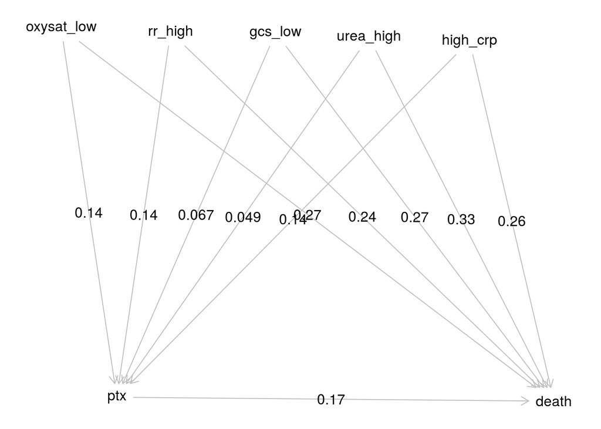

### Model 3A: Respiratory support

Modifications: Add NIV and IMV into model

```
## lavaan 0.6-7 ended normally after 175 iterations
##
##   Estimator                                       DWLS
##   Optimization method                           NLMINB
##   Number of free parameters                        128
##
##   Number of observations                         39158
##
## Model Test User Model:
##                                               Standard      Robust
##   Test Statistic                              7203.320    6836.736
##   Degrees of freedom                                16          16
##   P-value (Chi-square)                           0.000       0.000
##   Scaling correction factor                                  1.054
##   Shift parameter                                            1.006
##        simple second-order correction
##
## Parameter Estimates:
##
##   Standard errors                           Robust.sem
##   Information                                 Expected
##   Information saturated (h1) model        Unstructured
##
## Regressions:
##                    Estimate  Std.Err  z-value  P(>|z|)
##   death ~
##     ptx               0.133    0.026    5.073    0.000
##     age70             0.456    0.068    6.746    0.000
##     male             -0.025    0.019   -1.369    0.171
##     asthma            0.013    0.028    0.459    0.646
##     chronicpul       -0.018    0.042   -0.438    0.662
##     obesity          -0.051    0.027   -1.854    0.064
##     chrincard         0.148    0.023    6.394    0.000
##     hypertension     -0.026    0.019   -1.372    0.170
##     renal            -0.085    0.038   -2.244    0.025
##     mildliver         0.088    0.070    1.258    0.208
##     malignantneo      0.341    0.028   12.271    0.000
##     diabetes         -0.014    0.021   -0.657    0.511
##     oxysat_low        0.308    0.040    7.754    0.000
##     rr_high           0.284    0.037    7.637    0.000
```

[output cut: 146 more lines]

```
##    .gcs_low           1.000
##    .urea_high         1.000
##    .high_crp          1.000
##
## Scales y*:
##                    Estimate  Std.Err  z-value  P(>|z|)
##     death             1.000
##     ptx               1.000
##     IMV               1.000
##     NIV               1.000
##     oxysat_low        1.000
##     rr_high           1.000
##     gcs_low           1.000
##     urea_high         1.000
##     high_crp          1.000
```

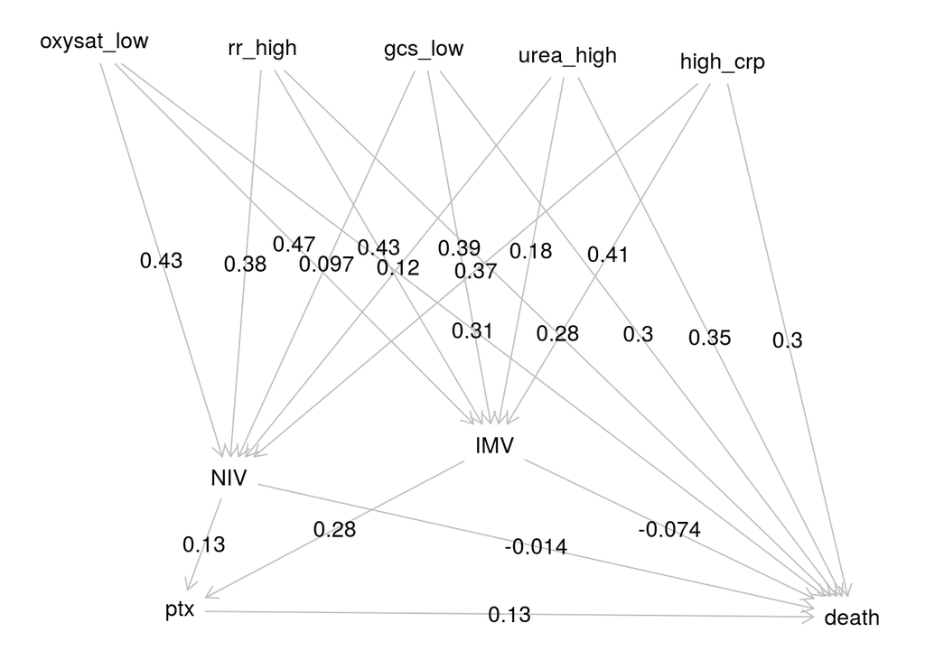

### Model 3B: Respiratory Support (NIV -> IMV)

Modifications: Add path from NIV to IMV

```
## lavaan 0.6-7 ended normally after 170 iterations
##
##   Estimator                                       DWLS
##   Optimization method                           NLMINB
##   Number of free parameters                        129
##
##   Number of observations                         39158
##
## Model Test User Model:
##                                               Standard      Robust
##   Test Statistic                              6526.776    6514.745
##   Degrees of freedom                                15          15
##   P-value (Chi-square)                           0.000       0.000
##   Scaling correction factor                                  1.002
##   Shift parameter                                            0.752
##        simple second-order correction
##
## Parameter Estimates:
##
##   Standard errors                           Robust.sem
##   Information                                 Expected
##   Information saturated (h1) model        Unstructured
##
## Regressions:
##                    Estimate  Std.Err  z-value  P(>|z|)
##   death ~
##     ptx               0.122    0.027    4.560    0.000
##     age70             0.555    0.036   15.489    0.000
##     male             -0.049    0.017   -2.853    0.004
##     asthma           -0.006    0.025   -0.258    0.797
##     chronicpul        0.028    0.027    1.024    0.306
##     obesity          -0.081    0.025   -3.244    0.001
##     chrincard         0.170    0.019    8.814    0.000
##     hypertension     -0.042    0.017   -2.478    0.013
##     renal            -0.044    0.026   -1.649    0.099
##     mildliver         0.079    0.065    1.215    0.224
##     malignantneo      0.353    0.026   13.491    0.000
##     diabetes         -0.019    0.020   -0.975    0.329
##     oxysat_low        0.244    0.017   14.634    0.000
##     rr_high           0.228    0.016   14.124    0.000
```

[output cut: 147 more lines]

```
##    .gcs_low           1.000
##    .urea_high         1.000
##    .high_crp          1.000
##
## Scales y*:
##                    Estimate  Std.Err  z-value  P(>|z|)
##     death             1.000
##     ptx               1.000
##     IMV               1.000
##     NIV               1.000
##     oxysat_low        1.000
##     rr_high           1.000
##     gcs_low           1.000
##     urea_high         1.000
##     high_crp          1.000
```

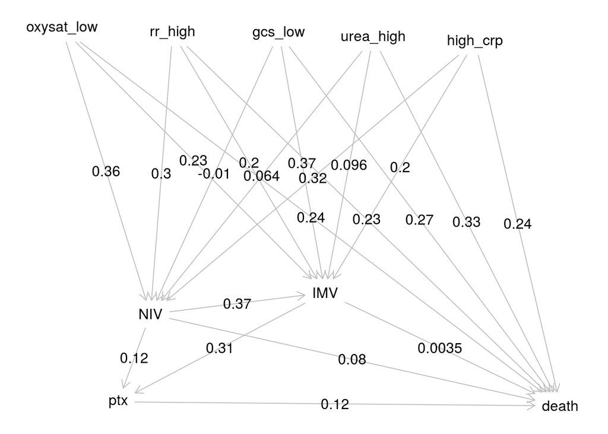

### Model 3C: Respiratory support (PTX -> IMV)

Modification: Causal link from ptx to IMV

```
## lavaan 0.6-7 ended normally after 176 iterations
##
##   Estimator                                       DWLS
##   Optimization method                           NLMINB
##   Number of free parameters                        128
##
##   Number of observations                         39158
##
## Model Test User Model:
##                                               Standard      Robust
##   Test Statistic                              6794.910    6415.840
##   Degrees of freedom                                16          16
##   P-value (Chi-square)                           0.000       0.000
##   Scaling correction factor                                  1.059
##   Shift parameter                                            0.933
##        simple second-order correction
##
## Parameter Estimates:
##
##   Standard errors                           Robust.sem
##   Information                                 Expected
##   Information saturated (h1) model        Unstructured
##
## Regressions:
##                    Estimate  Std.Err  z-value  P(>|z|)
##   death ~
##     ptx               0.228    0.107    2.126    0.033
##     age70             0.470    0.135    3.491    0.000
##     male             -0.037    0.024   -1.522    0.128
##     asthma            0.002    0.029    0.068    0.945
##     chronicpul       -0.025    0.093   -0.271    0.787
##     obesity          -0.055    0.035   -1.581    0.114
##     chrincard         0.159    0.032    5.032    0.000
##     hypertension     -0.024    0.028   -0.855    0.393
##     renal            -0.084    0.071   -1.186    0.236
##     mildliver         0.096    0.079    1.216    0.224
##     malignantneo      0.331    0.036    9.199    0.000
##     diabetes         -0.012    0.024   -0.502    0.615
##     oxysat_low        0.297    0.066    4.515    0.000
##     rr_high           0.275    0.060    4.604    0.000
```

[output cut: 146 more lines]

```
##    .gcs_low           1.000
##    .urea_high         1.000
##    .high_crp          1.000
##
## Scales y*:
##                    Estimate  Std.Err  z-value  P(>|z|)
##     death             1.000
##     ptx               1.000
##     IMV               1.000
##     NIV               1.000
##     oxysat_low        1.000
##     rr_high           1.000
##     gcs_low           1.000
##     urea_high         1.000
##     high_crp          1.000
```

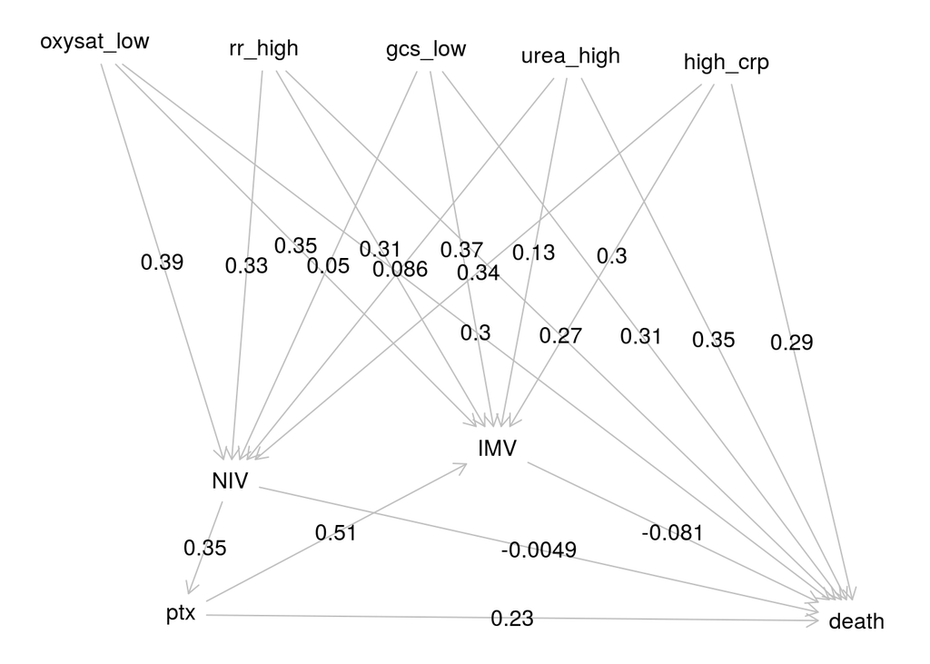

### Model 4: Steroids

Modification: Add steroids and effect of RECOVERY trial

```
## lavaan 0.6-7 ended normally after 178 iterations
##
##   Estimator                                       DWLS
##   Optimization method                           NLMINB
##   Number of free parameters                        148
##
##   Number of observations                         39158
##
## Model Test User Model:
##                                               Standard      Robust
##   Test Statistic                              8279.424    7962.292
##   Degrees of freedom                                27          27
##   P-value (Chi-square)                           0.000       0.000
##   Scaling correction factor                                  1.040
##   Shift parameter                                            1.706
##        simple second-order correction
##
## Parameter Estimates:
##
##   Standard errors                           Robust.sem
##   Information                                 Expected
##   Information saturated (h1) model        Unstructured
##
## Regressions:
##                    Estimate  Std.Err  z-value  P(>|z|)
##   death ~
##     ptx               0.132    0.026    5.045    0.000
##     age70             0.441    0.062    7.170    0.000
##     male             -0.025    0.019   -1.312    0.190
##     asthma            0.055    0.029    1.912    0.056
##     chronicpul        0.006    0.040    0.144    0.885
##     obesity          -0.045    0.028   -1.584    0.113
##     chrincard         0.149    0.023    6.404    0.000
##     hypertension     -0.025    0.020   -1.256    0.209
##     renal            -0.082    0.037   -2.235    0.025
##     mildliver         0.091    0.073    1.246    0.213
##     malignantneo      0.354    0.029   12.052    0.000
##     diabetes         -0.018    0.022   -0.814    0.415
##     oxysat_low        0.369    0.038    9.790    0.000
##     rr_high           0.330    0.035    9.404    0.000
```

[output cut: 170 more lines]

```
##    .urea_high         1.000
##    .high_crp          1.000
##
## Scales y*:
##                    Estimate  Std.Err  z-value  P(>|z|)
##     death             1.000
##     ptx               1.000
##     IMV               1.000
##     NIV               1.000
##     steroid           1.000
##     oxysat_low        1.000
##     rr_high           1.000
##     gcs_low           1.000
##     urea_high         1.000
##     high_crp          1.000
```

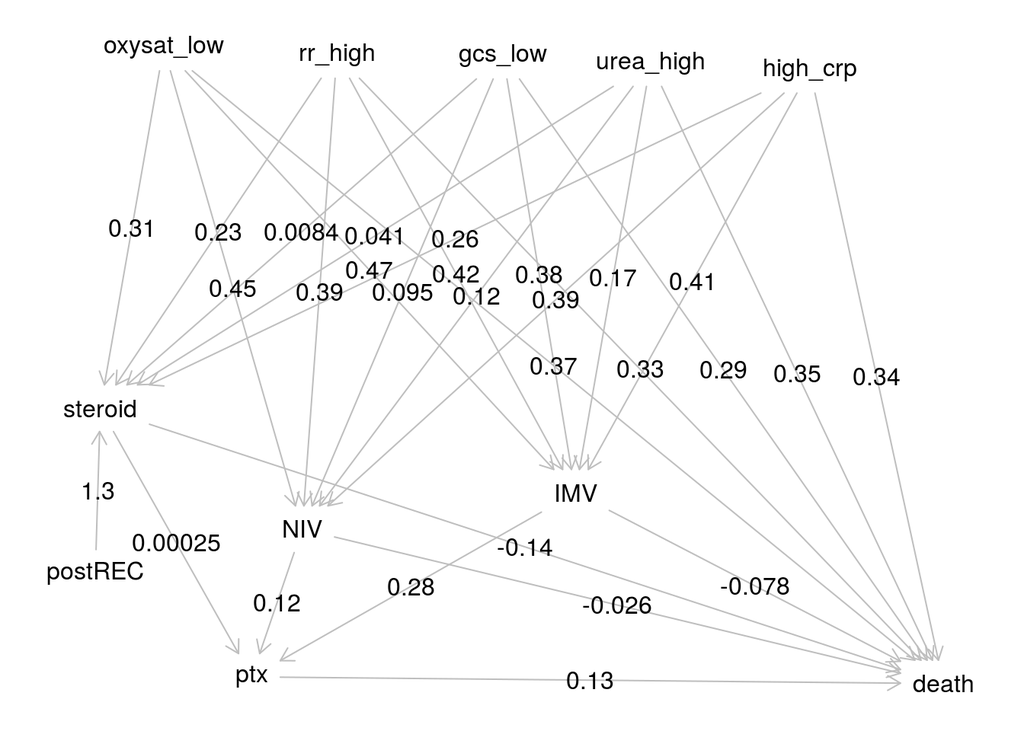